# econ_data_20210726_030519

2021/07/26 03:05:21 - Economy

```
Reports data directory not found.
Creating /Users/DidierRodriguesLopes/Documents/git/GamestonkTerminal/notebooks/reports/econ_data_20210726_030519
```

## Dow Jones - 2 year trend with 20, 50 and 200 day SMA

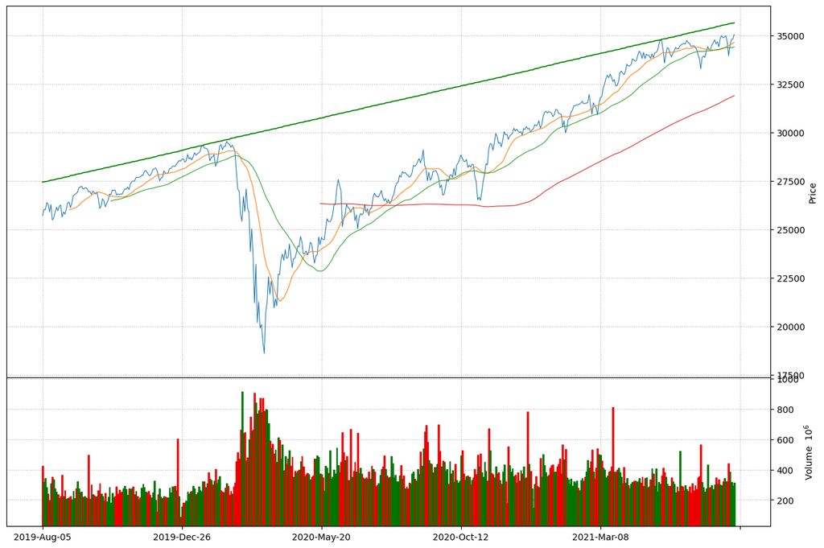

## Dow Jones - 1 year trend with 20, 50 and 200 day SMA

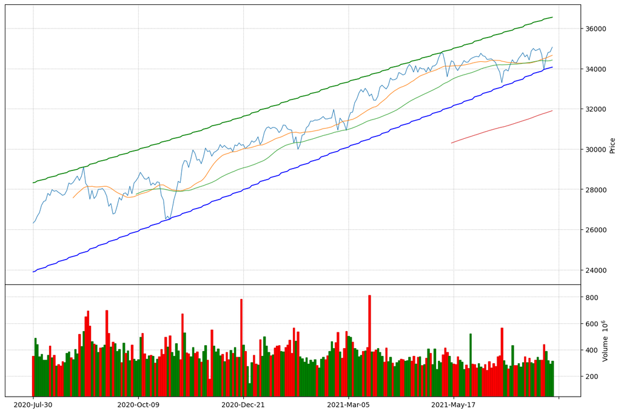

## S&P 500 - 2 year trend with 20, 50 and 200 day SMA

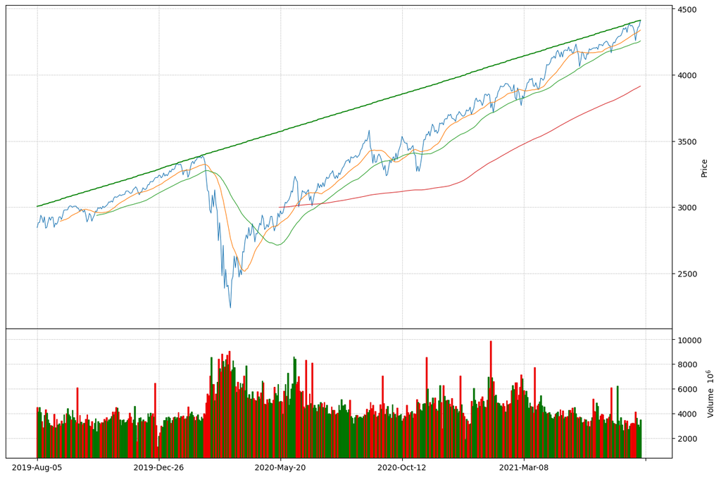

## Market Volatility (VIX) - 2 year trend with 20, 50 and 200 day SMA

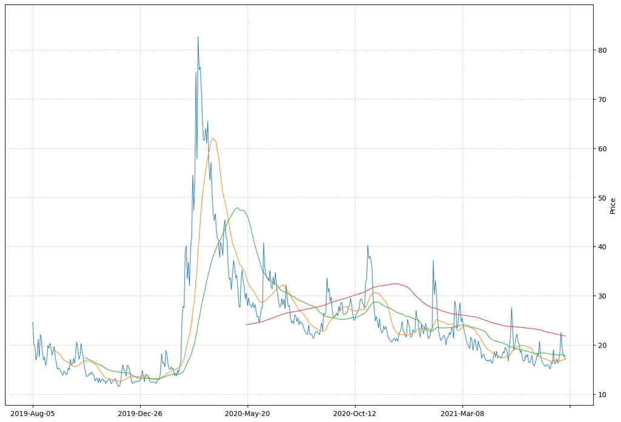

## Market Volatility (VIX) - 1 year trend with 20, 50 and 200 day SMA

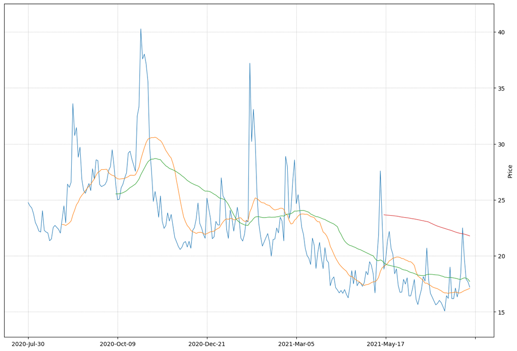

## Yield on 5-Year US Treasury Notes - 2 year trend with 20, 50 and 200 day SMA

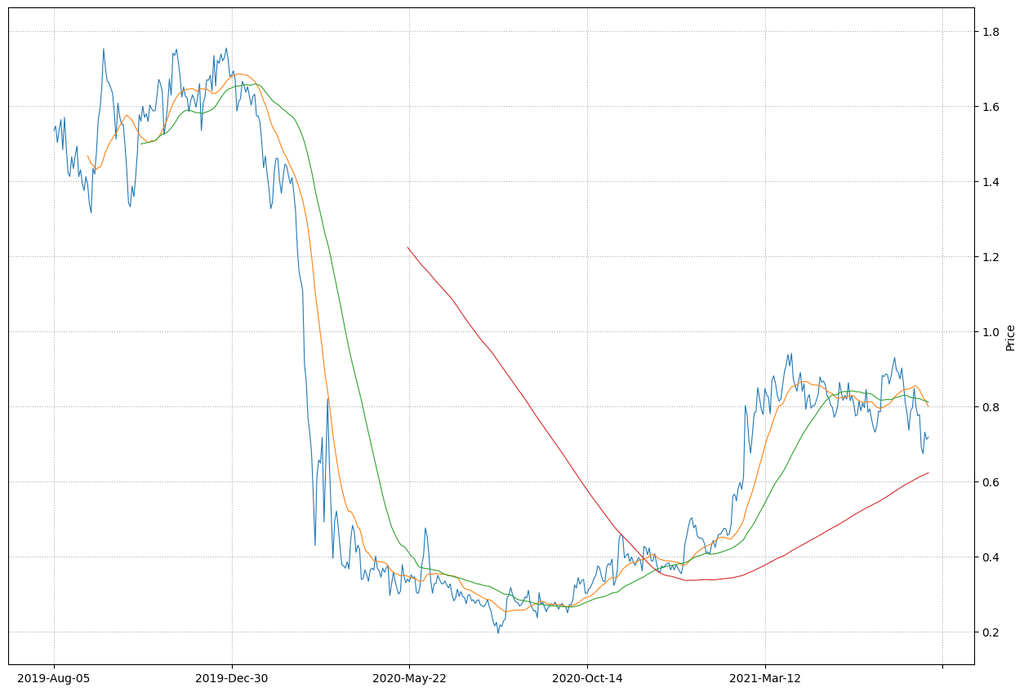

## Yield on 10-Year US Treasury Notes - 2 year trend with 20, 50 and 200 day SMA

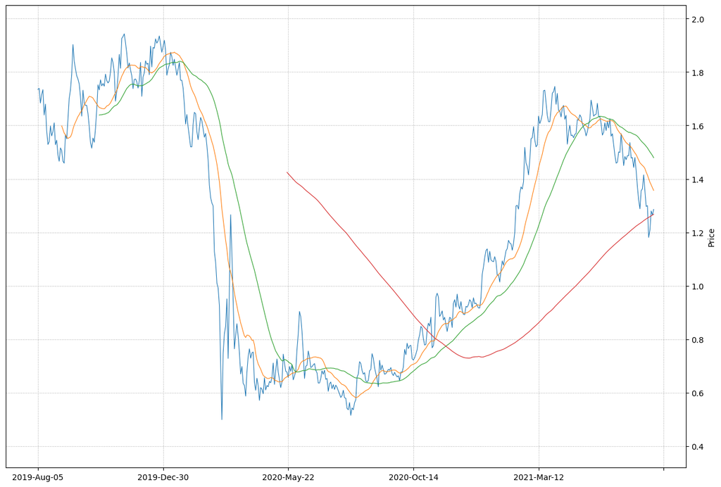

## Yield on 30-Year US Treasury Notes - 2 year trend with 20, 50 and 200 day SMA

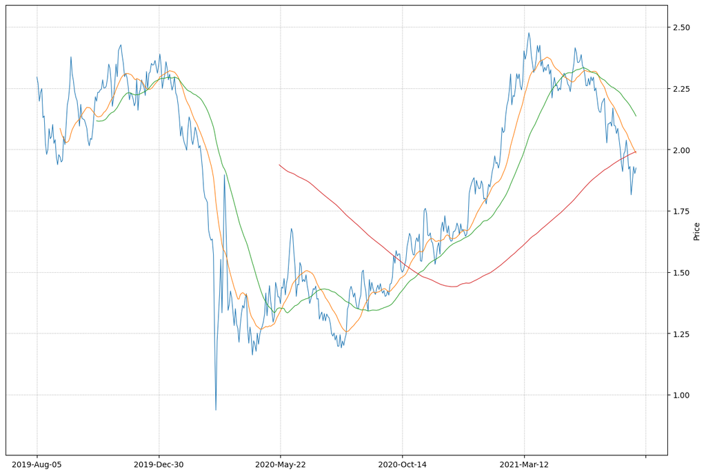

## Gold - 2 year trend with 20, 50 and 200 day SMA

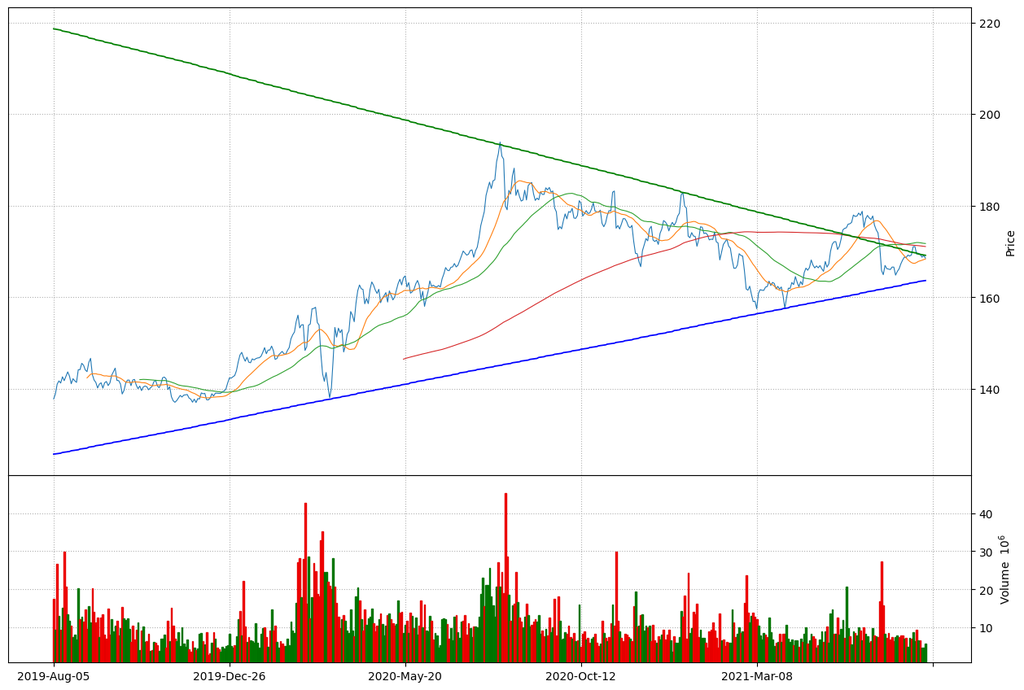

## Silver - 2 year trend with 20, 50 and 200 day SMA

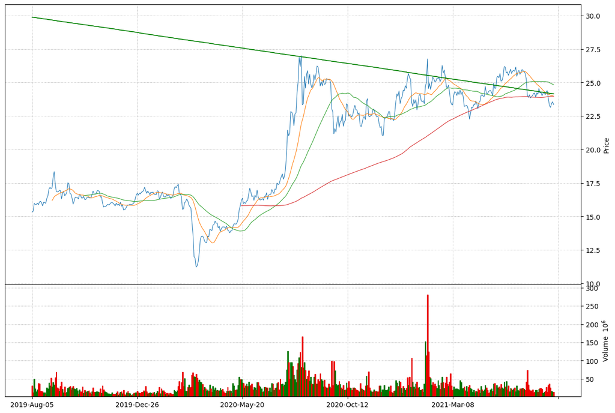

## Euro vs US Dollar - 2 year trend with 20, 50 and 200 day SMA

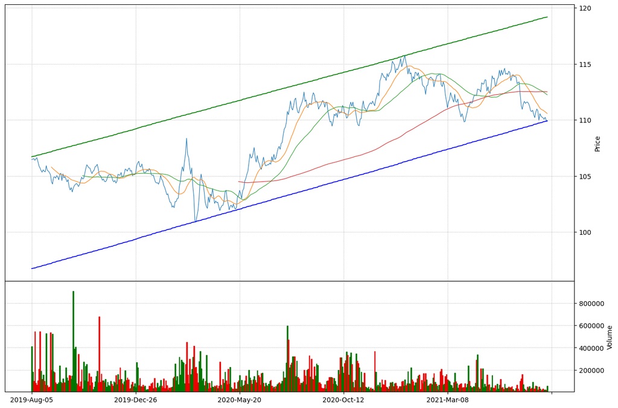

## Yen vs US Dollar - 2 year trend with 20, 50 and 200 day SMA

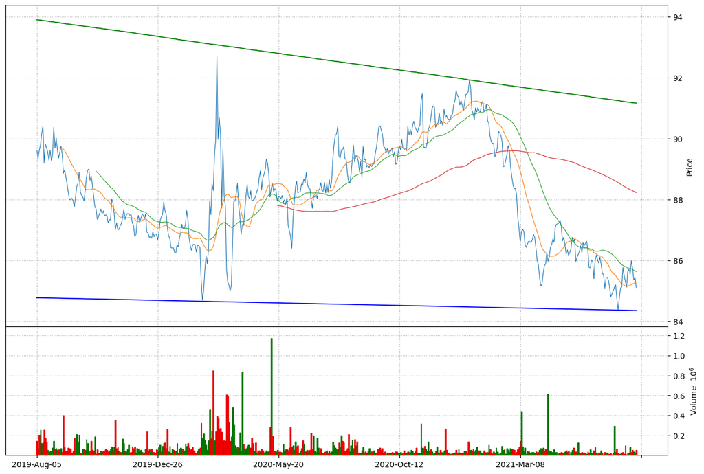

## Energy - 2 year trend with 20, 50 and 200 day SMA

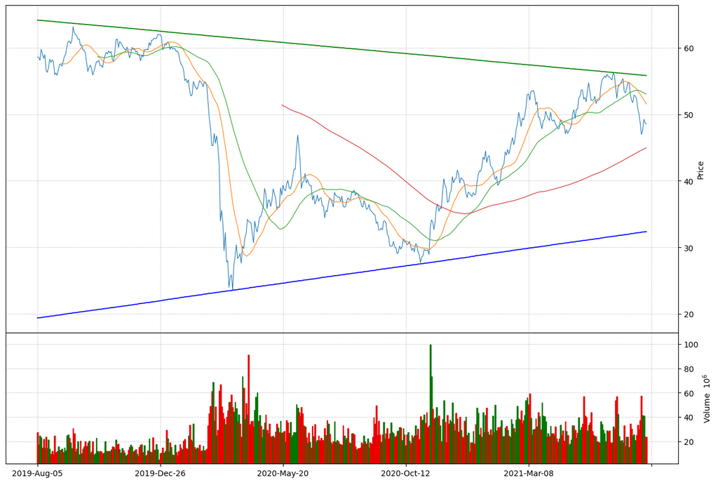

## Crude Oil - 2 year trend with 20, 50 and 200 day SMA

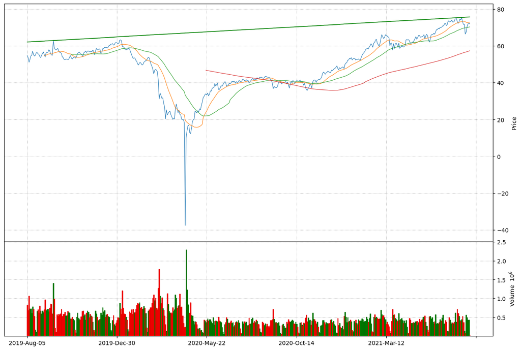

## Real Estate - 2 year trend with 20, 50 and 200 day SMA

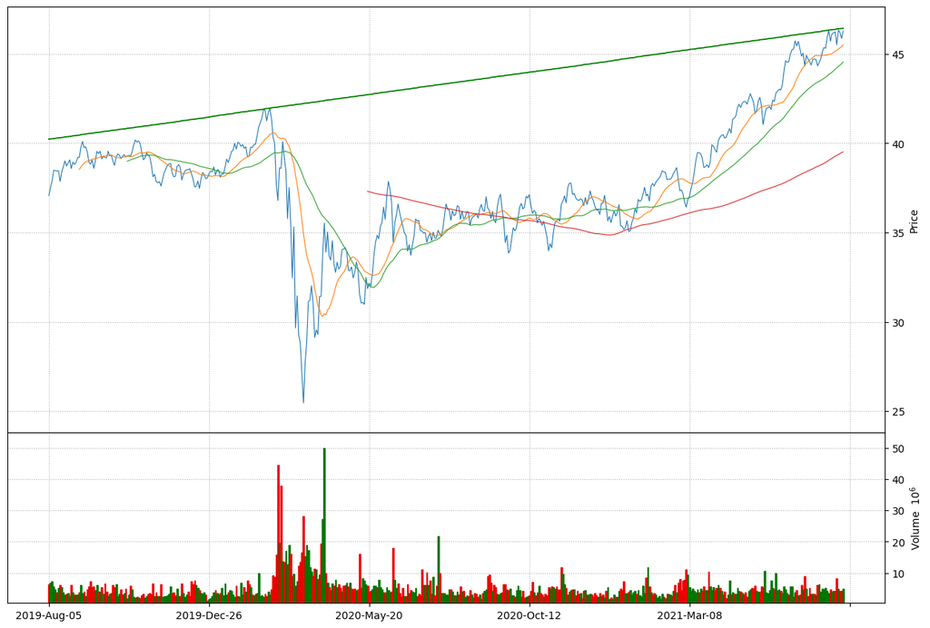

[figure not shown]

## Financials - 2 year trend with 20, 50 and 200 day SMA

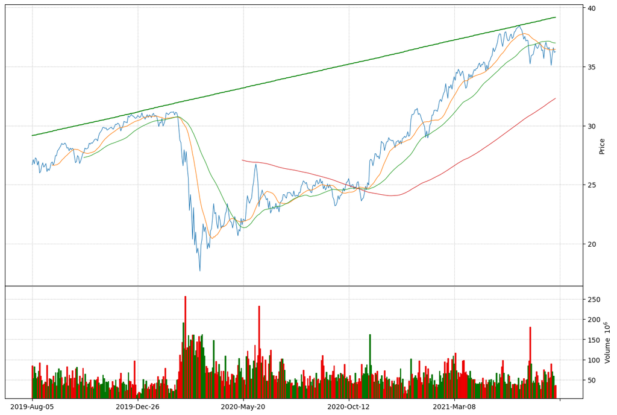

## Financials - 1 year trend with 20, 50 and 200 day SMA

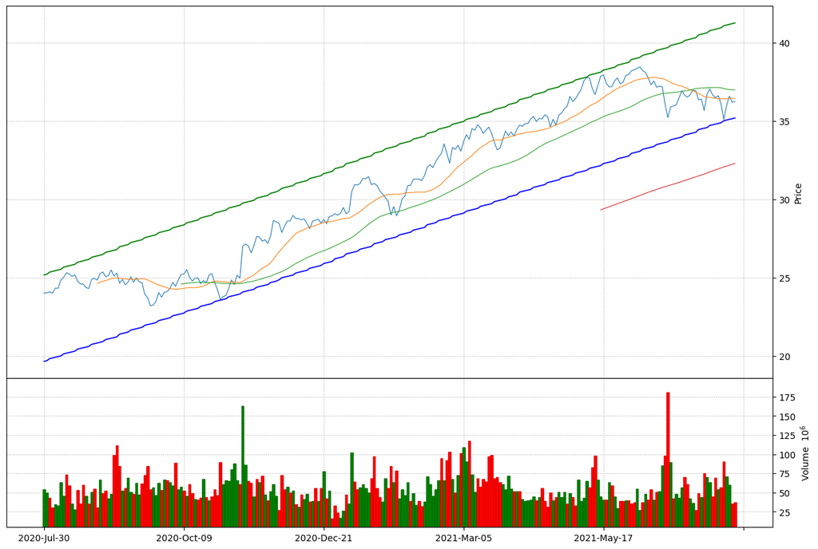

## Materials - 2 year trend with 20, 50 and 200 day SMA

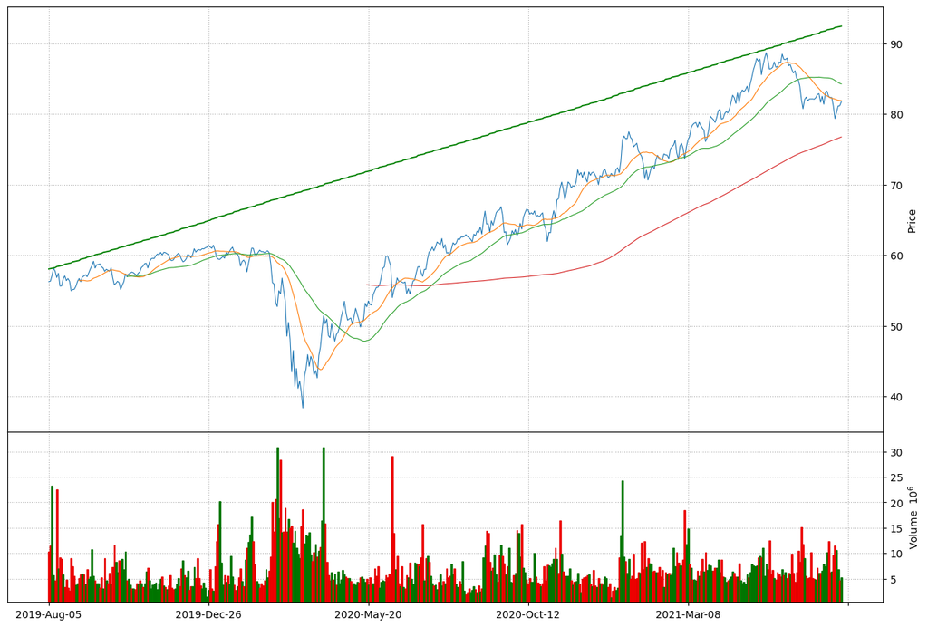

## Materials - 1 year trend with 20, 50 and 200 day SMA

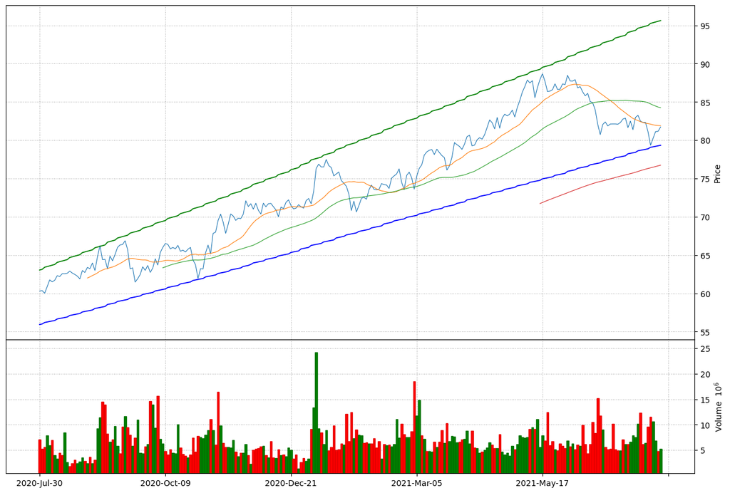